# Project 4

Vincent Barletta

2023-05-23

We will begin by reading in the four URLs for the pages that we are going to scrape. We build a basic function to get the access html format for each URL. For each step in the future, we will go descending levels to access the data that we want. On the main page with all the questions, our first navigation is to go into the questions div and pull the first element which contains all question information.

```r
#Four pages we want to scrape from
url1 <- "https://stackoverflow.com/questions/tagged/r?tab=newest&pagesize=50"
url2 <- "https://stackoverflow.com/questions/tagged/r?tab=newest&page=2&pagesize=50"
url3 <- "https://stackoverflow.com/questions/tagged/r?tab=newest&page=3&pagesize=50"
url4 <- "https://stackoverflow.com/questions/tagged/r?tab=newest&page=9817&pagesize=50"

#Initialize the first main page for scraping; we just go into questions Div and receive all 50 questions from the first page

page_generator <- function(url) {
  page <- read_html(url)
  main_page_questions <- page %>% html_nodes("div#questions")
  test_html <- main_page_questions[[1]]
  return(test_html)
}
```

For starters, we can get a lot of our information from the main list of questions. Let’s start with the views, answers, and votes. It reads in the page that we want to scrape everything from, and returns a dataframe. With 50 rows corresponding to each of the 50 questions on each URL that we pass in.

We start by going into the summary stats section of the HTML page, and cleaning up the new lines and other “r” characters using gsub. We then split up the different fields that we scrape unintentionally. These numbers are initially stored as characters. Next, we loop through all of the data that we find, and keep only the data that is a digit, as denoted by “d” in the gregexpr call.

Lastly, we combine all of our rows into a data frame with three columns: votes, answers, and views.

We include this first solely because we use it in our larger function down below and it must be initialized before call.

### Views, Answers, Votes

```r
views_answers_votes <- function(page) {

  summary_stats <- page %>% html_nodes('div.s-post-summary--stats.js-post-summary-stats') %>% html_text(trim=T) %>% gsub("\n","",.) %>% gsub("\r","",.)
  strsplit(summary_stats[1], split = " ")

  numbers_list <- list()

  # Iterate over each line in the table
  for (line in summary_stats) {
    # Extract numbers using regular expressions
    numbers <- as.numeric(regmatches(line, gregexpr("\\d+", line))[[1]])
    # Append the numbers to the list
    numbers_list <- c(numbers_list, list(numbers))
  }

  summary_stats_df <- as.data.frame(do.call(rbind, numbers_list))

  # Set the column names
  colnames(summary_stats_df) <- c("votes", "answer", "views")
  return(summary_stats_df)
}
```

### Post titles, Username, Rep, Time Posted, Tags (with Views Answers and Votes)

Now, we round off with all of the data that we can obtain from the main page, which I will refer to as the summary page. We start by using the URL we pass in to obtain the correct html page. The next section, “Initialize our primary paths”, essentially is used to shorten each long scraping operation by saving repetitive fields.

```r
question_summary_scraper <- function(url) {

  #Get the correct html head node
  test_html <- page_generator(url)

  #Initialize our primary paths for scraping data
  summary_content = test_html %>% html_nodes('div.s-post-summary--content')
  summary_depth = summary_content %>% html_nodes('div.s-post-summary--meta')
  user_card = summary_depth %>% html_nodes('div.s-user-card.s-user-card__minimal')

  #Scrape our basic data fields

  #Question Titles
  post_titles = summary_content %>% html_nodes('h3') %>% html_nodes('a') %>% xml_text

  #Username
  username = user_card  %>% html_nodes('div.s-user-card--info') %>% html_nodes('div.s-user-card--link.d-flex.gs4') %>% html_text(trim = T) %>% gsub("\n","",.) %>% gsub("\r","",.) %>% gsub("\\s+"," ",.)

  #Reputation
  rep = user_card  %>% html_nodes('div.s-user-card--info') %>% html_nodes('ul') %>% html_text(trim = T) %>% gsub("\n","",.) %>% gsub("\r","",.) %>% gsub("\\s+"," ",.)

  #Relative Time
  relative_time = user_card %>% html_nodes('time') %>% html_text(trim = T)

  #Secondary Tags
  secondary_tags = summary_content %>% html_nodes('div.s-post-summary--meta-tags') %>% html_text(trim=T)

  #Views, Answers, and Votes
  vav <- views_answers_votes(test_html)

  question_metadata <- data.frame(cbind(post_titles, username, rep, relative_time, secondary_tags, vav))
  return(question_metadata)
}
```

### Individual Question Scraping (Content, Badges, Most Recent Editor, Edit Time)

Now, we dive into the individual question pages. These functions follow the previous example by scraping small parts from each question page. We will have to do this for each of the 50 questions on each page, so we later utilize lapply from every question link.

The question_links function combines all of the sublinks with stackoverflow.com so that we can directly access each.

```r
#We next retrieve the link for each individual question in order to scrape further answer and comment information
base_url = "https://stackoverflow.com"

question_links <- function(url) {

  test_html <- page_generator(url)
  subquestion_links =  test_html %>% html_nodes('div.s-post-summary--content') %>% html_nodes('h3') %>% html_nodes('a') %>% html_attr('href')
  question_links = paste0(base_url, subquestion_links, sep = "")
  return(question_links)

}

question_content <- function(url) {
  page <- read_html(url)
  question_content <- page %>%
    html_nodes("div#question.question.js-question") %>%
    html_nodes("div.s-prose.js-post-body") %>%
    html_nodes("p") %>%
    html_text(trim = T)
  question_content <- paste(question_content, collapse = "")
  return(question_content)
}


question_badges <- function(question_links) {
    page2 <- read_html(question_links)
    user_badges = page2 %>% html_nodes("div.post-signature.owner.flex--item") %>% html_nodes("div.user-info")  %>% html_nodes("div.-flair") %>% html_nodes("span[title]") %>% html_attr("title")
    user_badges = user_badges[-1]
      user_badges = toString(user_badges)
    return(user_badges)
}


question_mre <- function(question_links) {

  page2 <- read_html(question_links)
   most_recent_editor = page2 %>% html_nodes("div.post-signature.flex--item") %>% html_nodes("div.user-info.user-hover")  %>% html_nodes("div.user-details") %>% html_nodes("a") %>% html_text(trim = T)
  most_recent_editor = most_recent_editor[1]

}

question_edit_time <- function(question_links) {

    page2 <- read_html(question_links)
    edit_time = page2 %>% html_nodes("div.post-signature.flex--item") %>% html_nodes("div.user-info.user-hover") %>% html_nodes("div.user-action-time") %>% html_text(trim = T)
  edit_time = edit_time[1]

}
```

Now, we go about collecting each comment to build out our overall answer column. The best format in order to store all of answer data would be in JSON. I am quite inexperienced with JSON, so instead we combine all of the data into a string. To access individual comments, we find the link within every answer path and loop each linkage to collect the text, name, and posting date for each comment for each answer for each question.

### Comment Data

```r
#Comments
retrieve_comment_path <- function(answer_path) {
  answer_path %>% html_nodes('div.post-layout--right.js-post-comments-component') %>% html_nodes("ul") %>% html_children()
}

# Define the function to scrape comment data
scrape_comments <- function(comment_paths) {
  comment_data <- list()

  for (i in seq_along(comment_paths)) {
    comment_path <- comment_paths[[i]]

    comment_text <- comment_path %>%
      html_nodes("div.comment-text") %>%
      html_nodes("div.comment-body") %>%
      html_nodes("span.comment-copy") %>%
      html_text(trim = TRUE)

    comment_name <- comment_path %>%
      html_nodes("div.comment-text") %>%
      html_nodes("div.comment-body") %>%
      html_nodes("div.d-inline-flex") %>%
      html_nodes("a") %>%
      html_text(trim = TRUE)

    comment_date <- comment_path %>%
      html_nodes("div.comment-text") %>%
      html_nodes("div.comment-body") %>%
      html_nodes("span.comment-date") %>%
      html_text(trim = TRUE)

    comment_stuff <- paste(comment_text, comment_name, comment_date, sep = " ")

    # Add comment data to the list
    comment_data[[i]] <- comment_stuff
  }
  #Convert it to string to combine the multiple sublistings into a string
  comment_string <- toString(comment_data)
  return(comment_string)
}
```

### Answer Information

We start by getting the individual pieces of the answer information. For the comment information, we use the previous comment scraping method. We loop through all answers available for each question page. Then, we combine all of our data, all answers together, and return it as a string that will conveniently fit into a singular data field. Otherwise, it is stuck as a nested list for multiple answers, which makes it much more difficult to combine into a data frame eventually.

```r
scrape_answers <- function(page) {

  page <- read_html(page)
  answer_data <- list()
  answer_path = page %>% html_nodes("div#answers") %>% html_nodes('div.answer')

    for (i in seq_along(answer_path)) {
      answer <- answer_path[i]

      #Answer Text
      answer_text = answer %>% html_nodes('div.post-layout') %>% html_nodes('div.answercell.post-layout--right') %>% html_nodes('div.s-prose.js-post-body') %>% html_nodes('p') %>% html_text(trim=T)
      answer_text = toString(answer_text)

      #Votes
      answer_votes = as.numeric(answer %>% html_nodes('div.post-layout') %>% html_nodes('div.votecell.post-layout--left') %>% html_nodes('div.js-voting-container') %>% html_nodes('div.js-vote-count') %>% html_text(trim=T))

      #Time
      answer_time = answer %>% html_nodes('div.post-layout') %>% html_nodes('div.answercell.post-layout--right') %>% html_nodes('div.mt24') %>% html_nodes('div.user-info') %>% html_nodes('div.user-action-time') %>% html_nodes('span') %>% html_text(trim = T)
      answer_time = answer_time[1]

      #Username
      answer_username = answer %>% html_nodes('div.post-layout') %>% html_nodes('div.answercell.post-layout--right') %>% html_nodes('div.mt24') %>% html_nodes('div.user-info') %>% html_nodes('div.user-details') %>% html_nodes('a') %>% html_text(trim = T)

      #Reputation (WIP)
      answer_reputation = (answer %>% html_nodes('div.post-layout') %>% html_nodes('div.answercell.post-layout--right') %>% html_nodes('div.mt24') %>% html_nodes('div.user-info') %>% html_nodes('div.user-details') %>% html_nodes('div.-flair') %>% html_children() %>% html_text(trim = T))[1]

      #Badges
      answer_badges = answer %>% html_nodes('div.post-layout') %>% html_nodes('div.answercell.post-layout--right') %>% html_nodes('div.mt24') %>% html_nodes('div.user-info') %>% html_nodes('div.user-details') %>% html_nodes('div.-flair') %>% html_nodes("span[title]") %>% html_attr("title")
      answer_badges = answer_badges[-1]
      answer_badges = toString(answer_badges)

      # Comments
      comment_path = retrieve_comment_path(answer)
      if(length(comment_path) != 0) {
        comment_data = scrape_comments(comment_path)
      } else {
        comment_data = NA
      }

      answer_stuff <- paste("Username:", answer_username, "Votes:", answer_votes, "Time:", answer_time,  "Reputation:", answer_reputation, "Badges:", answer_badges, "Answer:",answer_text, "Comments:", comment_data,  sep = " ")

      answer_data[[i]] <- answer_stuff

    }
  answer_string <- toString(answer_data)
  return(answer_string)
}
```

Finally, we use lapply to scrape the data for each link in the 50 page list. This makes a LOT of HTTP requests to the StackOverflow website. Unfortunately, that has given me timeouts for making too many requests. Therefore, at this point, I am unsure if it can fully gather all four dataframes in one go. If I had more time, I would find a workaround that is less computationally expensive.

```r
lapply_columns_1 <- function(question_links) {

  question_edit_l <- lapply(question_links, question_edit_time)
  question_editt_df <- as.data.frame(do.call(rbind, question_edit_l))
  colnames(question_editt_df) <- "Question_Edit_Time"

  question_mre_lapply <- lapply(question_links, question_mre)
  question_mre_df <- as.data.frame(do.call(rbind, question_mre_lapply))
  colnames(question_mre_df) <- "Question_Most_Recent_Editor"

  question_badges_l <- lapply(question_links, question_badges)
  question_badges_df <- as.data.frame(do.call(rbind, question_badges_l))
  colnames(question_badges_df) <- "Question_Badges"

   df <- as.data.frame(cbind(question_badges_df, question_mre_df, question_editt_df))
   colnames(df) <- c("Question_Edit_Time", "Question_Most_Recent_Editor", "Question_Badges")
  return(df)

}

lapply_columns_2 <- function(question_links) {

  questions <- lapply(question_links, question_content)
  question_content_df <- as.data.frame(do.call(rbind, questions))
  colnames(question_content_df) <- "Question Text"

  answers_lap <- lapply(question_links, scrape_answers)
  answers_df <- as.data.frame(do.call(rbind, answers_lap))
  colnames(answers_df) <- "Answer Data"

  df <- as.data.frame(cbind(question_content_df, answers_df))
   colnames(df) <- c("Question Text", "Answer Data")

  return(df)
}
```

```r
q1 <- question_links(url1)
q2 <- question_links(url2)
q3 <- question_links(url3)
q4 <- question_links(url4)
```

I understand that would make my assignment incomplete, but I have an example that displays we are able to get all of the final data for at least the first page.

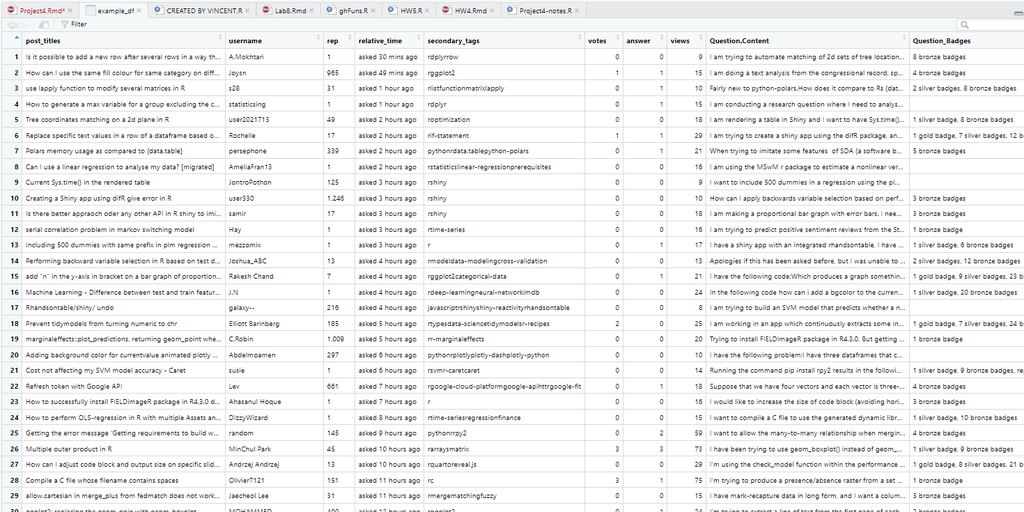

Data Table Ex1

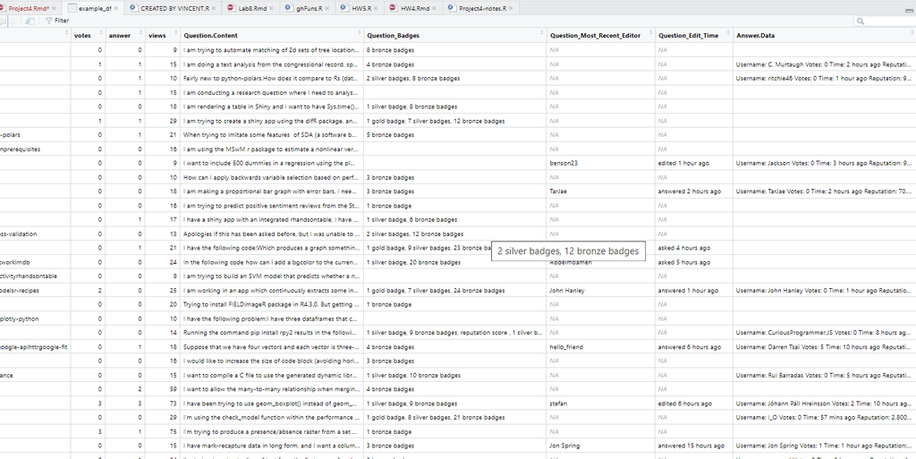

Data Table Ex2

### Page 1 Data

```r
lapply_q1_1 <- lapply_columns_1(q1)
lapply_q1_2 <- lapply_columns_2(q1)
qss1 <- question_summary_scraper(url1)
page1data<- data.frame(cbind(qss1,lapply_q1_1, lapply_q1_2))
head(page1data)
```

```
##                                                                                            post_titles
## 1                                                                                    AUC for SVM model
## 2                                                            Finding shortest paths between nodes in R
## 3                                                how to create a tibble from a list with named vectors
## 4                     How can I subtract values of each column of my dataframe from all other columns?
## 5                                         Unable to install Gtk2 on Windows using different R versions
## 6 How to create a continuous geom_line across a facet boundaries in ggplot2 over the time series data?
##          username rep     relative_time            secondary_tags votes answer
## 1 Bradford Patton   1  asked 5 mins ago                         r     0      0
## 2          jayjay   1 asked 17 mins ago                         r     0      0
## 3         pandora  47  asked 1 hour ago                         r     0      2
## 4            Lara 117  asked 1 hour ago                         r     0      3
## 5             Tom   1  asked 1 hour ago                     rgtk2     1      0
## 6     Rony Golder  75  asked 1 hour ago rggplot2time-seriesx-axis     1      0
##   views              Question_Edit_Time Question_Most_Recent_Editor
```

[output cut: 27 more lines]

### Page 2 Data

```r
lapply_q2_1 <- lapply_columns_1(q2)
lapply_q2_2 <- lapply_columns_2(q2)
qss2 <- question_summary_scraper(url2)
page2data <- data.frame(cbind(qss2,lapply_q2_1, lapply_q2_2))
head(page2data)
```

```
##                                                                                       post_titles
## 1                                                           ggplot - reorder_within - Order month
## 2                     ggplot - ordering legends with guides changes continuous legend to discrete
## 3                            How can I put the iterable numbers into a new column each iteration?
## 4 How to add multiple column headers that span specified columns to a DT table rendered in Shiny?
## 5                         Python or R packages to draw 2D diagrams of intermolecular interactions
## 6                                                 aggregating model summaries from list of models
##                      username   rep   relative_time
## 1   Guilherme Lopes de Campos    19 asked yesterday
## 2                  pcantalupo 2,204 asked yesterday
## 3                        Lara   117 asked yesterday
## 4 Curious Jorge - user9788072 2,286 asked yesterday
## 5                        ginn    93 asked yesterday
## 6                   bison2178   713 asked yesterday
##                     secondary_tags votes answer views
```

[output cut: 34 more lines]

### Page 3 Data

```r
#lapply_q3_1 <- lapply_columns_1(q3)
#lapply_q3_2 <- lapply_columns_2(q3)
#qss3 <- question_summary_scraper(url3)
#page3data <- data.frame(cbind(qss3,lapply_q3_1, lapply_q3_2))
#head(page3data)
```

### Final Page Data

```r
#lapply_q4_1 <- lapply_columns_1(q4)
#lapply_q4_2 <- lapply_columns_2(q4)
#qss4 <- question_summary_scraper(url4)
#page4data<- data.frame(cbind(qss4,lapply_q4_1, lapply_q4_2))
#head(page4data)
```